# Understanding and Predicting Credit Card Churn: An In-Depth Analysis of Customer Attrition in The Credit card industry

### Standard Deviation

The calculation of standard deviations for various attributes in the credit card dataset serves as a fundamental statistical analysis, offering valuable insights into data dispersion and variability. This metric is of particular significance in the financial industry as it contributes to understanding how essential attributes like “Customer_Age,” “Credit_Limit,” “Months_on_book,” “Avg_Open_To_Buy,” “Avg_Utilization_Ratio,” “Total_Revolving_Bal,” “Total_Trans_Amt,” and “Total_Trans_Ct” are distributed. Standard deviation provides a measure of how much these variables deviate from their respective means. A higher standard deviation indicates greater data variability or dispersion, whereas a lower standard deviation suggests that values are more closely clustered around the mean. By computing and summarizing standard deviations for these attributes, financial analysts can glean insights into the levels of risk and variability associated with different aspects of customer credit profiles.

Furthermore, standard deviations are instrumental in guiding data-driven decision-making processes within the financial sector. They help identify attributes that display significant variations, potentially highlighting areas where financial institutions should implement more targeted risk management strategies or customize their services accordingly. Additionally, standard deviations play a crucial role in portfolio management and the assessment of financial product volatility. A clear understanding of the range of key variables such as “Credit_Limit” or “Total_Trans_Amt” is vital for pricing models and evaluating customer creditworthiness. By effectively interpreting and applying the standard deviations of these attributes, financial institutions can make informed decisions to enhance their risk assessment procedures and provide better service to their customers.

```
##          Customer_Age          Credit_Limit       Total_Trans_Amt
##                 8.017              9088.777              3397.129
##       Avg_Open_To_Buy        Months_on_book Avg_Utilization_Ratio
##              9090.685                 7.986                 0.276
##   Total_Revolving_Bal        Total_Trans_Ct
##               814.987                23.473
```

### Exploratory Data Analysis of Categorical Variables

EDA enables the identification of patterns, trends, and associations within categorical data. This can be vital for making informed decisions, understanding customer behavior, or recognizing significant factors that impact outcomes.

In the “Data Distribution” section, the ggplot2 library is utilized for visualizing how categorical variables are distributed within the dataset. These visual representations play a crucial role in understanding the distribution of different attributes, including “Attrition_Flag,” “Gender,” “Education_Level,” “Marital_Status,” “Income_Category,” and “Card_Category.” The bar graphs offer a clear overview of the frequency of each category within these attributes. This analysis is instrumental in revealing patterns, frequencies, and variations, which are essential for comprehending customer segments and their behavior in the context of credit card usage.

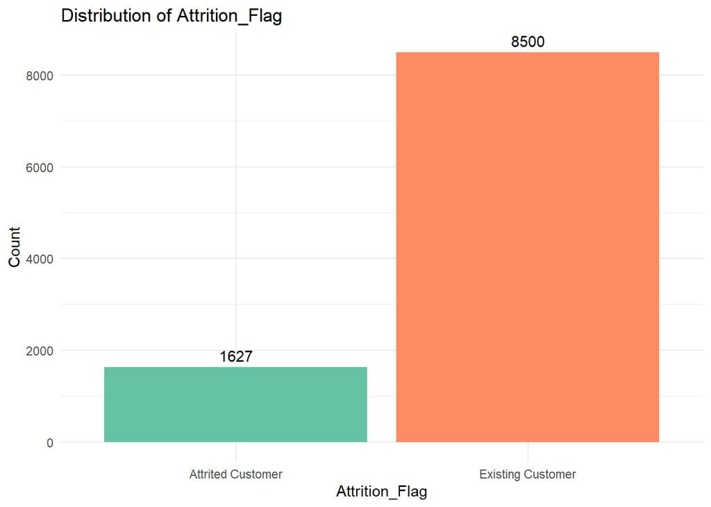

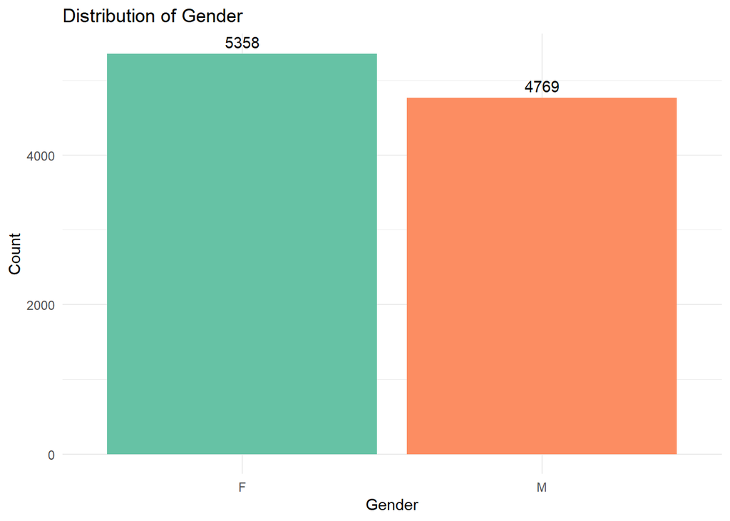

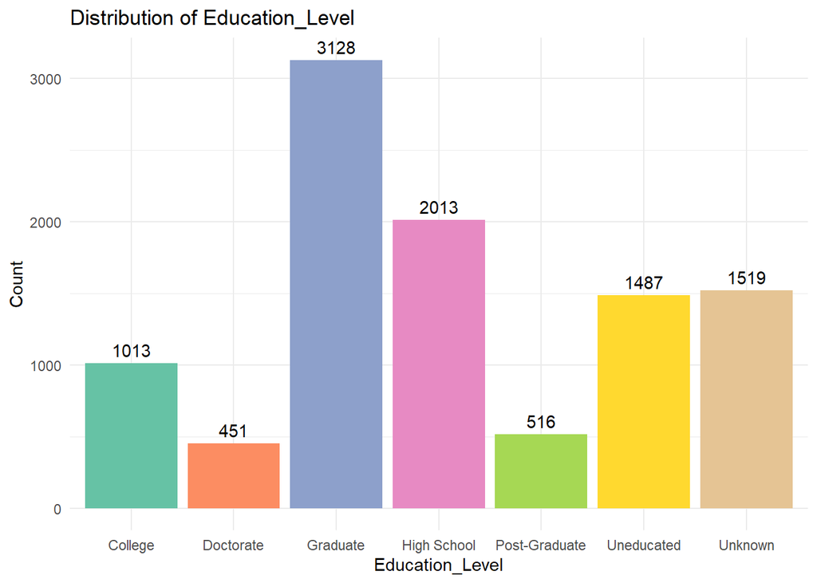

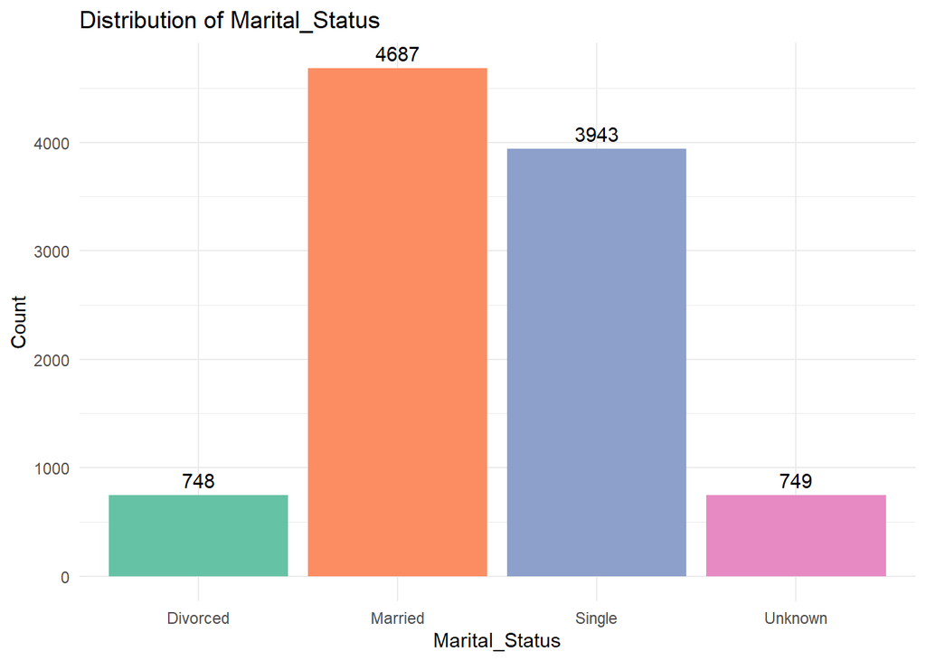

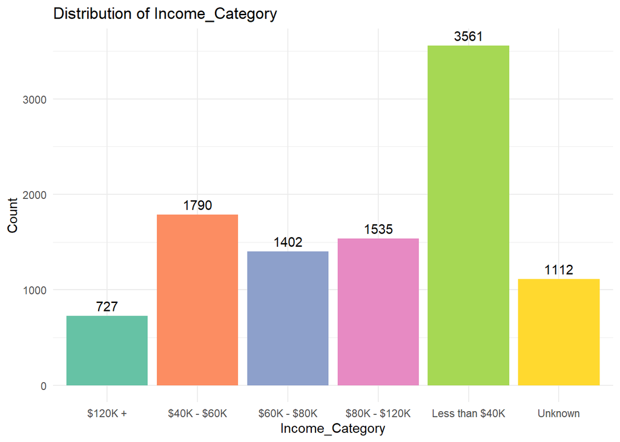

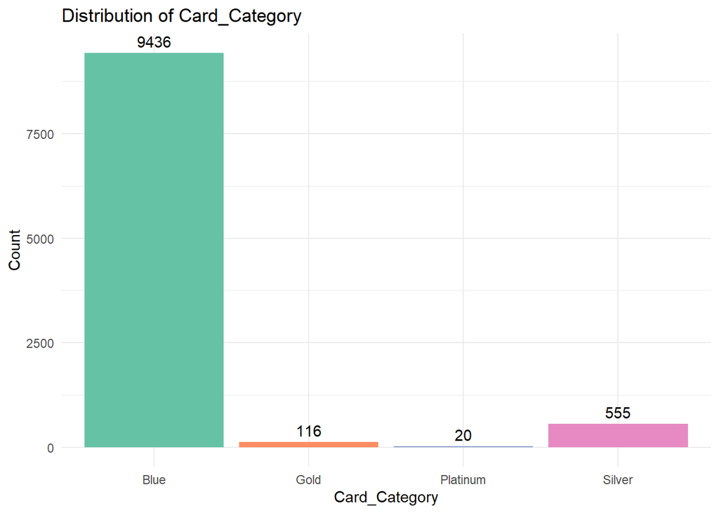

### Exploratory Data Analysis of Numerical Variables

The exploratory data analysis (EDA) conducted on the dataset primarily emphasizes its numerical variables, providing valuable insights into key financial attributes of the customers. Specifically, a detailed examination is carried out on variables such as “Customer_Age,” “Total_Trans_Amt,” “Total_Trans_Ct,” and “Credit_Limit.” Utilizing histograms and density curves, the EDA unveils significant information about the financial behaviors and characteristics of the customers.

For instance, the “Customer_Age” histogram, using a bin width of 3, offers a comprehensive view of the age distribution among the customer base. This visualization aids in determining whether the customer population exhibits a skew toward a specific age group or displays noticeable gaps or anomalies in age distribution. Such findings can guide targeted marketing efforts and inform product development strategies.

Transitioning to attributes related to customer transactions, the histograms for “Total_Trans_Amt” and “Total_Trans_Ct” are crucial in understanding customer spending patterns. With bin widths of 500 and 7, respectively, these visualizations reveal the distribution of total transaction amounts and counts. They play a pivotal role in identifying concentration ranges and identifying potential outliers within the transaction data. This knowledge can be instrumental in shaping strategies for customer engagement, loyalty programs, and adjustments to credit limits (with binwidths of 800). In essence, the EDA of numerical variables establishes a foundation for more advanced data analysis, empowering data scientists and business analysts to make data-informed decisions and customize financial offerings for better customer service.

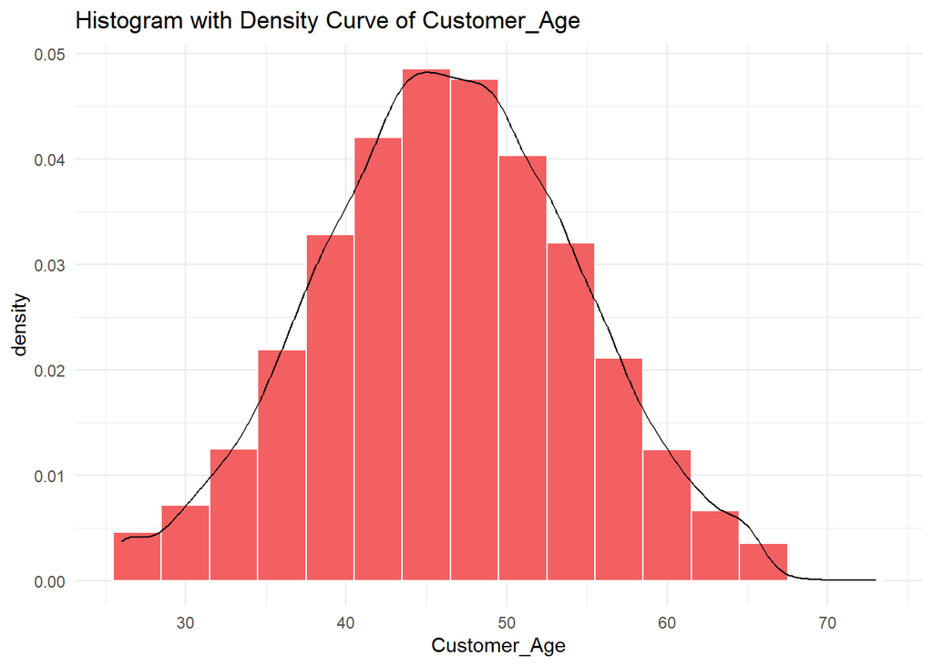

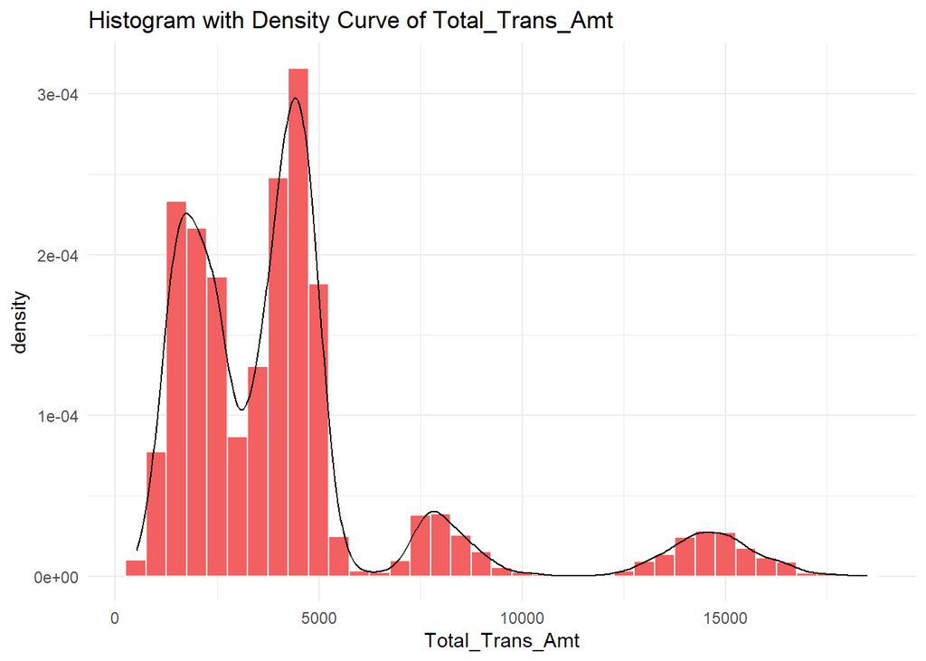

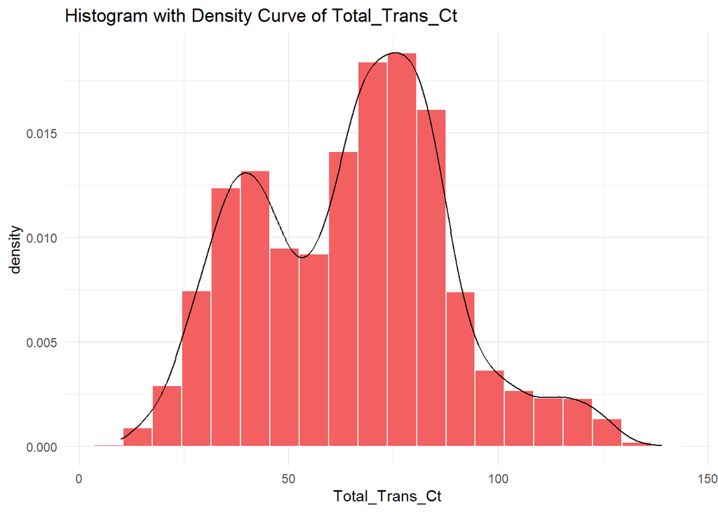

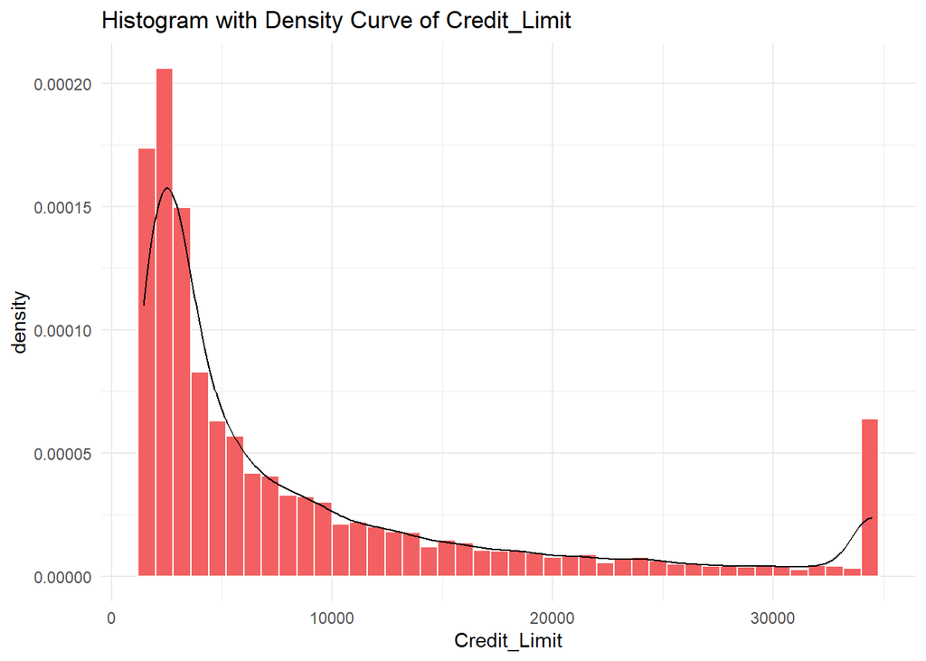